# level 2 - Project 2 - Dataset - [Link](https://www.kaggle.com/datasets/yasserh/wine-quality-dataset)

### Name: Priyanshu Priya

### Data Analytics Internship @OASIS INFOBYTE

### ID: OIB/J1/IP4664

## Task Description:

The focus is on predicting the quality of wine based on its chemical characteristics, offering a real-world application of machine learning in the context of viticulture. The dataset encompasses diverse chemical attributes, including density and acidity, which serve as the features for three distinct classifier models.

## 1. Importing Libraries

```python
import pandas as pd
import numpy as np
import seaborn as sns
import matplotlib.pyplot as plt
import warnings
warnings.filterwarnings('ignore')
from sklearn.model_selection import train_test_split, cross_val_score
from sklearn.ensemble import RandomForestClassifier
from sklearn.linear_model import SGDClassifier
from sklearn.svm import SVC
from sklearn.preprocessing import StandardScaler
from sklearn.metrics import accuracy_score, precision_score, recall_score, f1_score, confusion_matrix, classification_report
```

### 2. Data Loading and Understanding

```python
df=pd.read_csv(r"WineQT.csv")
```

```python
df.head()
```

|  | fixed acidity | volatile acidity | citric acid | residual sugar | chlorides | free sulfur dioxide | total sulfur dioxide | density | pH | sulphates | alcohol | quality | Id |
| --- | --- | --- | --- | --- | --- | --- | --- | --- | --- | --- | --- | --- | --- |
| 0 | 7.4 | 0.70 | 0.00 | 1.9 | 0.076 | 11.0 | 34.0 | 0.9978 | 3.51 | 0.56 | 9.4 | 5 | 0 |
| 1 | 7.8 | 0.88 | 0.00 | 2.6 | 0.098 | 25.0 | 67.0 | 0.9968 | 3.20 | 0.68 | 9.8 | 5 | 1 |
| 2 | 7.8 | 0.76 | 0.04 | 2.3 | 0.092 | 15.0 | 54.0 | 0.9970 | 3.26 | 0.65 | 9.8 | 5 | 2 |
| 3 | 11.2 | 0.28 | 0.56 | 1.9 | 0.075 | 17.0 | 60.0 | 0.9980 | 3.16 | 0.58 | 9.8 | 6 | 3 |
| 4 | 7.4 | 0.70 | 0.00 | 1.9 | 0.076 | 11.0 | 34.0 | 0.9978 | 3.51 | 0.56 | 9.4 | 5 | 4 |

```python
df.info()
```

```
<class 'pandas.core.frame.DataFrame'>
RangeIndex: 1143 entries, 0 to 1142
Data columns (total 13 columns):
 #   Column                Non-Null Count  Dtype
---  ------                --------------  -----
 0   fixed acidity         1143 non-null   float64
 1   volatile acidity      1143 non-null   float64
 2   citric acid           1143 non-null   float64
 3   residual sugar        1143 non-null   float64
 4   chlorides             1143 non-null   float64
 5   free sulfur dioxide   1143 non-null   float64
 6   total sulfur dioxide  1143 non-null   float64
 7   density               1143 non-null   float64
 8   pH                    1143 non-null   float64
 9   sulphates             1143 non-null   float64
 10  alcohol               1143 non-null   float64
 11  quality               1143 non-null   int64
 12  Id                    1143 non-null   int64
dtypes: float64(11), int64(2)
memory usage: 116.2 KB
```

```python
df.shape
```

```
(1143, 13)
```

```python
df.columns
```

```
Index(['fixed acidity', 'volatile acidity', 'citric acid', 'residual sugar',
       'chlorides', 'free sulfur dioxide', 'total sulfur dioxide', 'density',
       'pH', 'sulphates', 'alcohol', 'quality', 'Id'],
      dtype='object')
```

```python
df.describe().T
```

|  | count | mean | std | min | 25% | 50% | 75% | max |
| --- | --- | --- | --- | --- | --- | --- | --- | --- |
| fixed acidity | 1143.0 | 8.311111 | 1.747595 | 4.60000 | 7.10000 | 7.90000 | 9.100000 | 15.90000 |
| volatile acidity | 1143.0 | 0.531339 | 0.179633 | 0.12000 | 0.39250 | 0.52000 | 0.640000 | 1.58000 |
| citric acid | 1143.0 | 0.268364 | 0.196686 | 0.00000 | 0.09000 | 0.25000 | 0.420000 | 1.00000 |
| residual sugar | 1143.0 | 2.532152 | 1.355917 | 0.90000 | 1.90000 | 2.20000 | 2.600000 | 15.50000 |
| chlorides | 1143.0 | 0.086933 | 0.047267 | 0.01200 | 0.07000 | 0.07900 | 0.090000 | 0.61100 |
| free sulfur dioxide | 1143.0 | 15.615486 | 10.250486 | 1.00000 | 7.00000 | 13.00000 | 21.000000 | 68.00000 |
| total sulfur dioxide | 1143.0 | 45.914698 | 32.782130 | 6.00000 | 21.00000 | 37.00000 | 61.000000 | 289.00000 |
| density | 1143.0 | 0.996730 | 0.001925 | 0.99007 | 0.99557 | 0.99668 | 0.997845 | 1.00369 |
| pH | 1143.0 | 3.311015 | 0.156664 | 2.74000 | 3.20500 | 3.31000 | 3.400000 | 4.01000 |
| sulphates | 1143.0 | 0.657708 | 0.170399 | 0.33000 | 0.55000 | 0.62000 | 0.730000 | 2.00000 |
| alcohol | 1143.0 | 10.442111 | 1.082196 | 8.40000 | 9.50000 | 10.20000 | 11.100000 | 14.90000 |
| quality | 1143.0 | 5.657043 | 0.805824 | 3.00000 | 5.00000 | 6.00000 | 6.000000 | 8.00000 |
| Id | 1143.0 | 804.969379 | 463.997116 | 0.00000 | 411.00000 | 794.00000 | 1209.500000 | 1597.00000 |

## Checking for Missing Values

```python
df.isnull().sum()
```

```
fixed acidity           0
volatile acidity        0
citric acid             0
residual sugar          0
chlorides               0
free sulfur dioxide     0
total sulfur dioxide    0
density                 0
pH                      0
sulphates               0
alcohol                 0
quality                 0
Id                      0
dtype: int64
```

No missing values present

### 3. EDA

#### 3.1 Feature Distribution

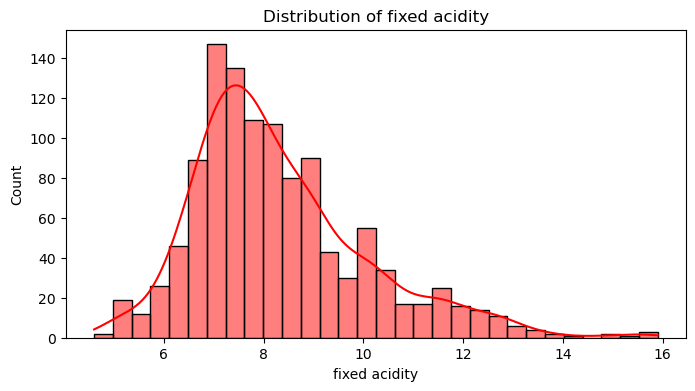

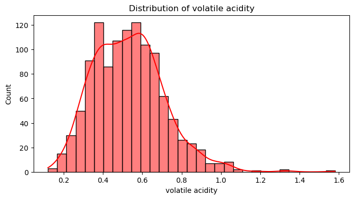

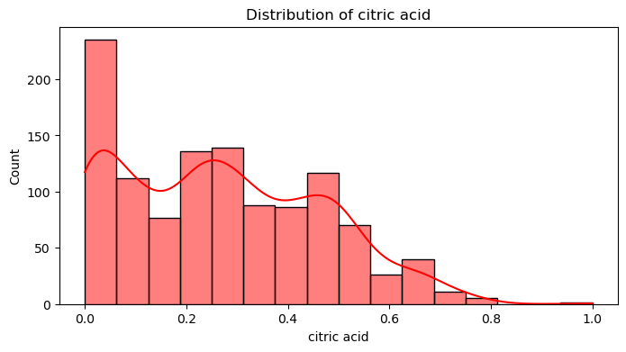

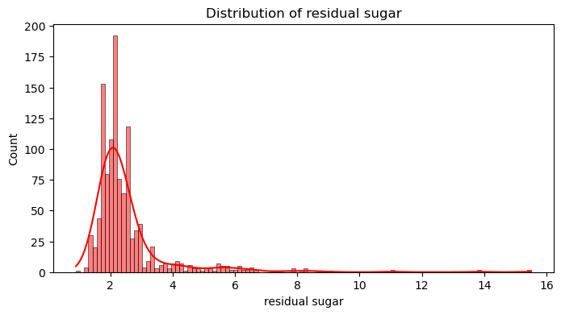

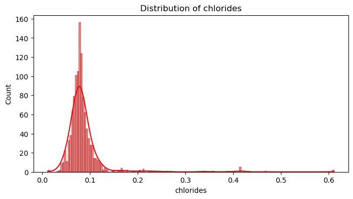

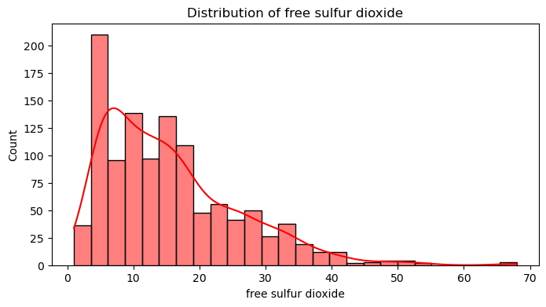

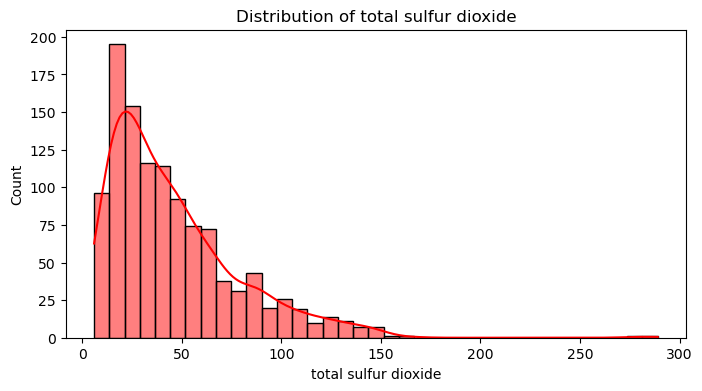

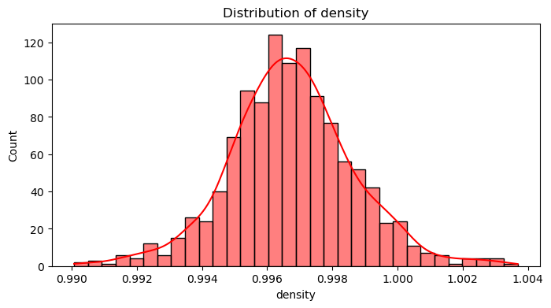

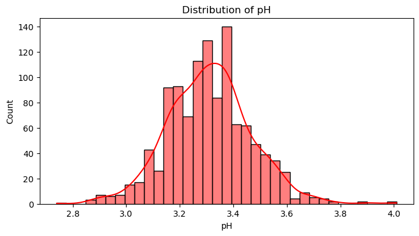

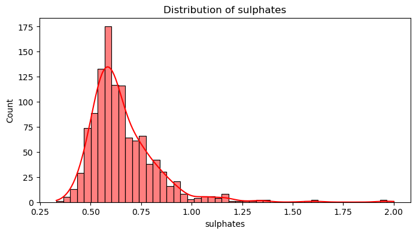

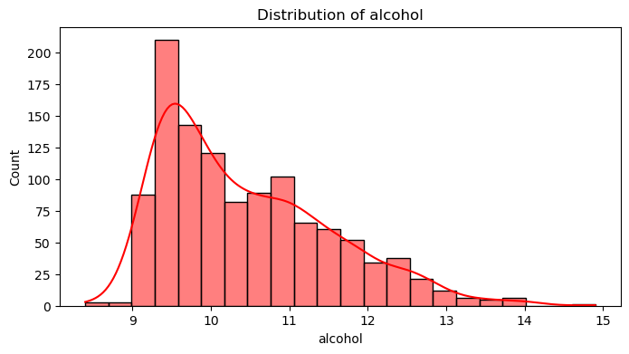

```python
for col in df.columns[:-2]:  # Exclude 'quality' and 'Id'
    plt.figure(figsize=(8, 4))
    sns.histplot(df[col], kde=True,color='Red')
    plt.title(f"Distribution of {col}")
    plt.show()
```

### 3.2 Feature vs. Quality Box Plots

1. Using box plots to examine the distribution of each feature across different wine quality levels.
2. This can highlight trends, such as whether higher acidity correlates with higher quality.

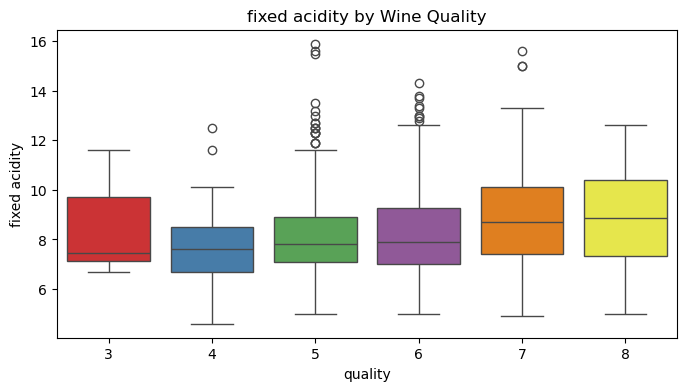

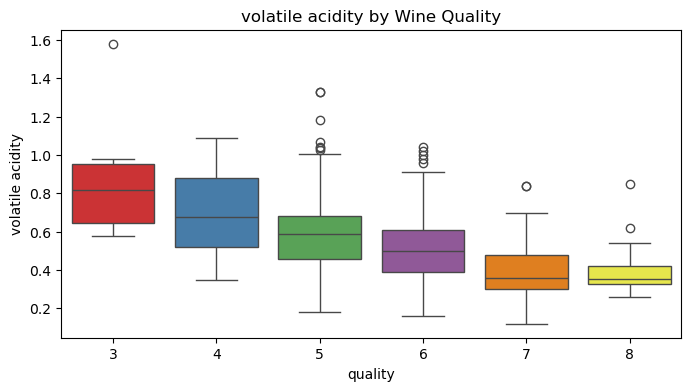

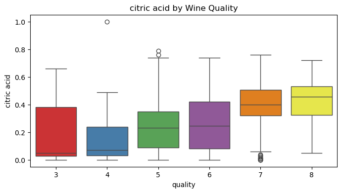

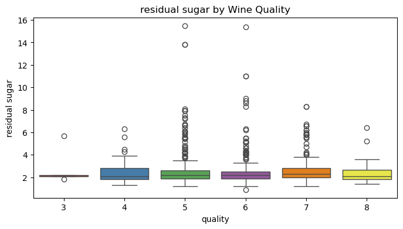

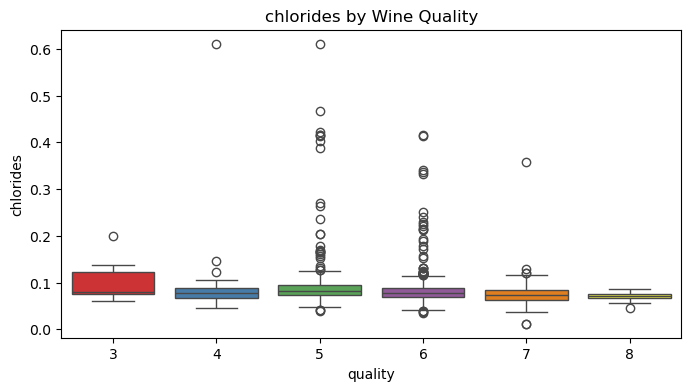

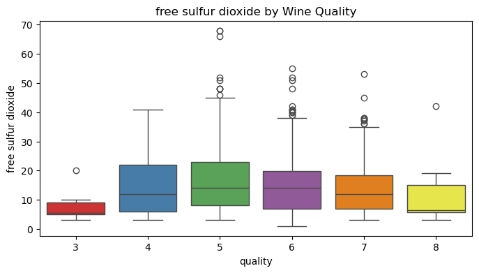

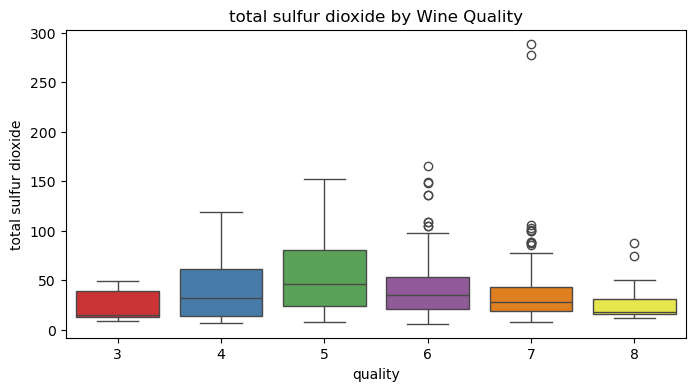

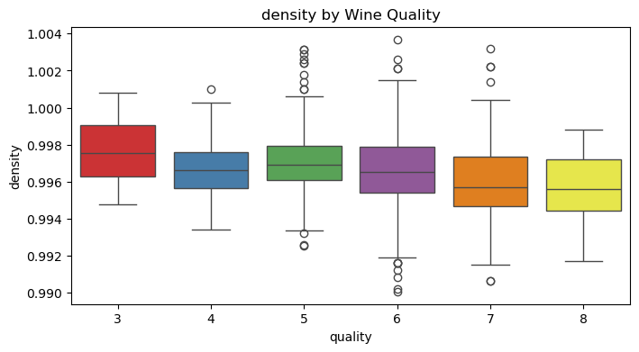

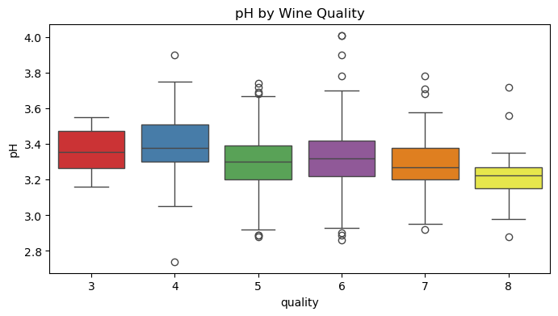

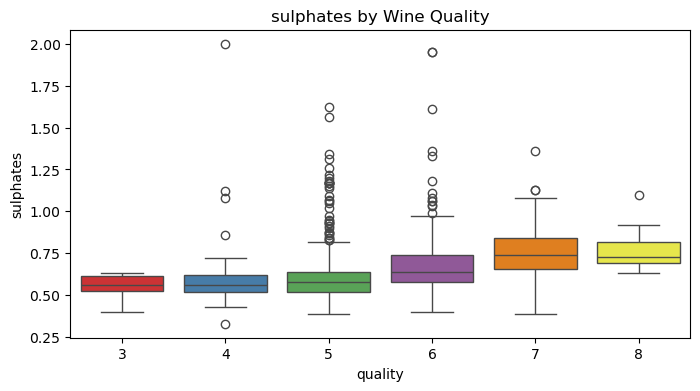

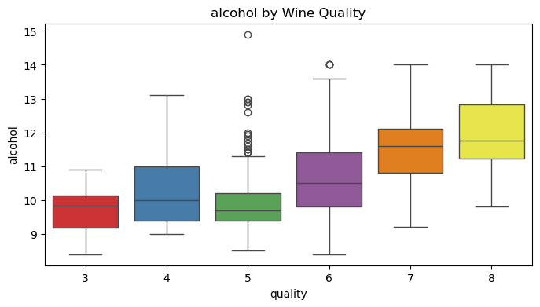

```python
for col in df.columns[:-2]:  # Exclude 'quality' and 'Id'
    plt.figure(figsize=(8, 4))
    sns.boxplot(x='quality', y=col, data=df,palette='Set1')
    plt.title(f"{col} by Wine Quality")
    plt.show()
```

### 3.3 Pair Plot:

Visualizing relationships between pairs of features, colored by wine quality. This can reveal clusters or separations between quality levels.

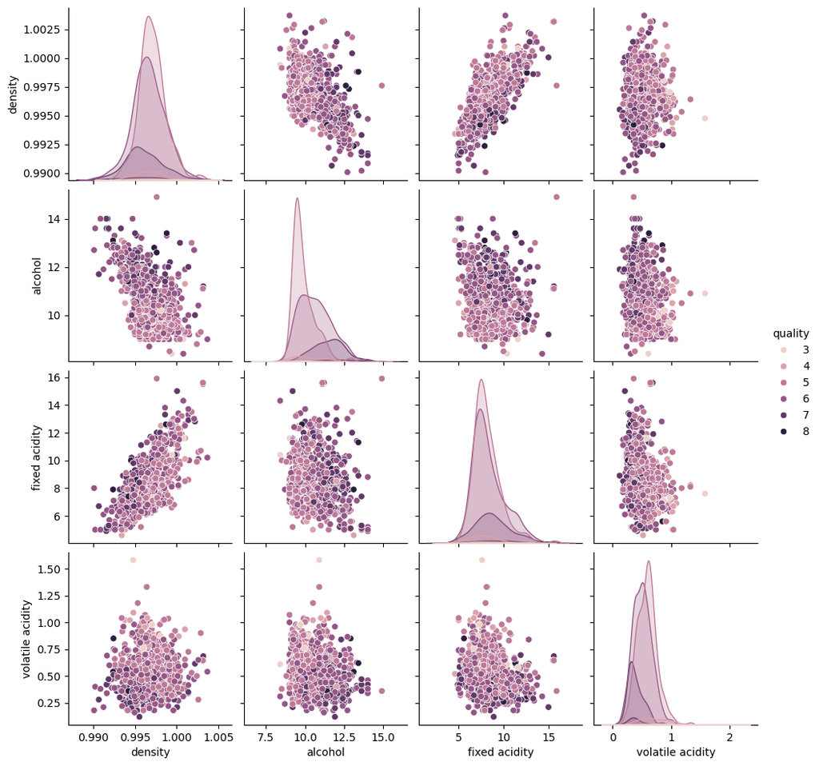

```python
sns.pairplot(df, vars=['density', 'alcohol', 'fixed acidity', 'volatile acidity'], hue='quality')
plt.show()
```

### 3.4 Heatmap of Correlations

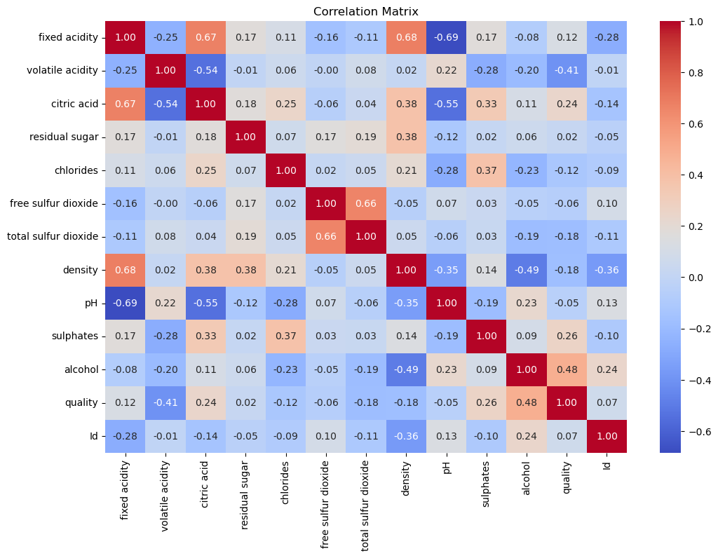

```python
plt.figure(figsize=(12, 8))
sns.heatmap(df.corr(), annot=True, cmap='coolwarm', fmt=".2f")
plt.title("Correlation Matrix")
plt.show()
```

### 3.5 Density and Alcohol Interaction:

Since density and alcohol are known to influence wine quality, plot a scatter plot of these two features colored by quality.

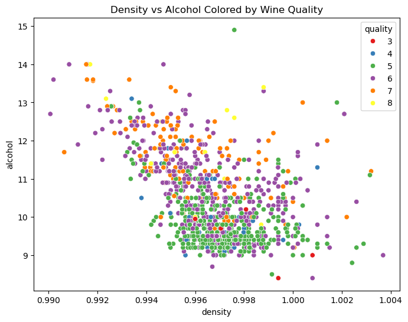

```python
plt.figure(figsize=(8, 6))
sns.scatterplot(x='density', y='alcohol', hue='quality', data=df, palette='Set1')
plt.title("Density vs Alcohol Colored by Wine Quality")
plt.show()
```

### 3.6 pH vs Acidity Analysis:

Examining the relationship between pH and fixed acidity/volatile acidity, as acidity levels and pH are inversely related but impact quality.

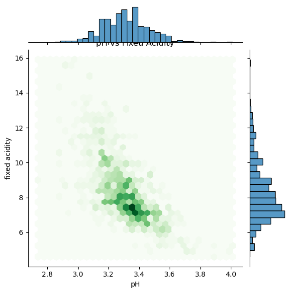

```python
sns.jointplot(x='pH', y='fixed acidity', data=df, kind='hex', cmap='Greens')
plt.title("pH vs Fixed Acidity")
plt.show()
```

### 3.7 Sulfur Dioxide Impact:

Ploting free sulfur dioxide and total sulfur dioxide against quality to understand if these preservatives affect quality.

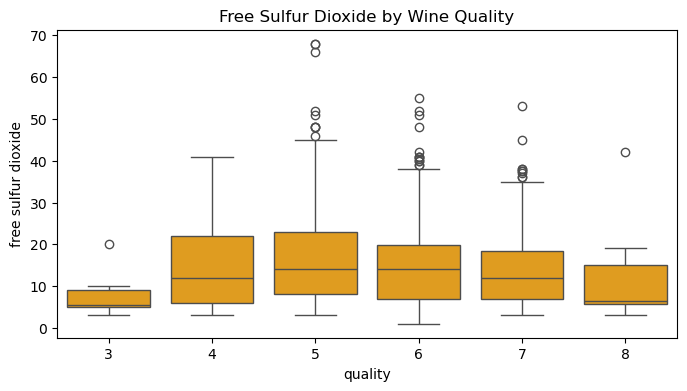

```python
plt.figure(figsize=(8, 4))
sns.boxplot(x='quality', y='free sulfur dioxide', data=df,color='Orange')
plt.title("Free Sulfur Dioxide by Wine Quality")
plt.show()
```

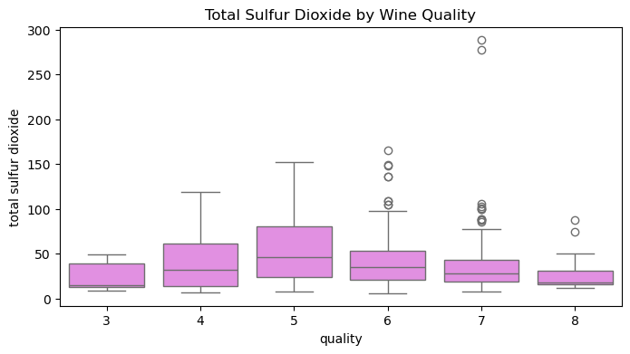

```python
plt.figure(figsize=(8, 4))
sns.boxplot(x='quality', y='total sulfur dioxide', data=df,color='Violet')
plt.title("Total Sulfur Dioxide by Wine Quality")
plt.show()
```

### 4. Data Pre-processing

### 4.1 Feature Selection

1. Exclude the Id column: This is an identifier, so it doesn't contribute to the prediction of wine quality.
2. Set quality as the target variable and use all other features (excluding Id) as predictors

```python
# Drop the Id column
df = df.drop(columns=['Id'])

# Define features (X) and target (y)
X = df.drop(columns=['quality'])  # Features
y = df['quality']  # Target variable
```

### 4.2 Feature Engineering Insights

Calculating ratios, such as volatile acidity / fixed acidity, to see if the balance between different types of acidity correlates with quality.

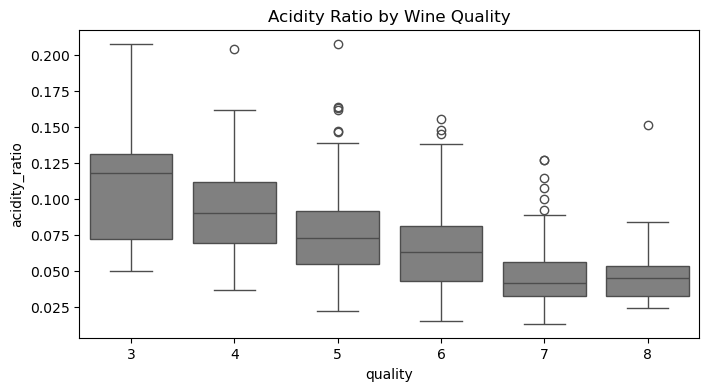

```python
df['acidity_ratio'] = df['volatile acidity'] / df['fixed acidity']
plt.figure(figsize=(8, 4))
sns.boxplot(x='quality', y='acidity_ratio', data=df,color='Gray')
plt.title("Acidity Ratio by Wine Quality")
plt.show()
```

### Log-Transformations for Skewed Data

Applying a log transformation on skewed features, like residual sugar or chlorides, if their distribution is highly skewed. Re-evaluate feature distributions after transformations.

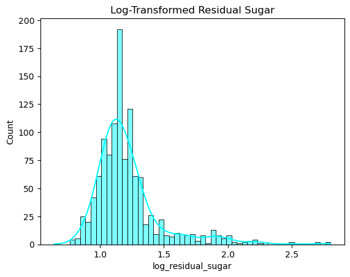

```python
df['log_residual_sugar'] = np.log1p(df['residual sugar'])
sns.histplot(df['log_residual_sugar'], kde=True,color='Cyan')
plt.title("Log-Transformed Residual Sugar")
plt.show()
```

### Principal Component Analysis (PCA)

Using PCA to reduce the feature space to 2-3 dimensions, and visualize how wine samples cluster based on quality in the reduced space.

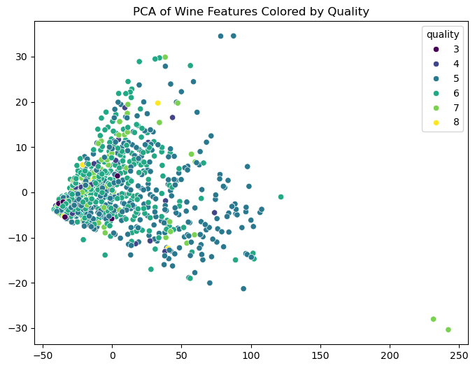

```python
from sklearn.decomposition import PCA
pca = PCA(n_components=2)
X_pca = pca.fit_transform(df.drop(['quality'], axis=1))

plt.figure(figsize=(8, 6))
sns.scatterplot(x=X_pca[:, 0], y=X_pca[:, 1], hue=df['quality'], palette='viridis')
plt.title("PCA of Wine Features Colored by Quality")
plt.show()
```

### 4.3 Data Scaling

```python
from sklearn.preprocessing import StandardScaler

# Standardize the features
scaler = StandardScaler()
X_scaled = scaler.fit_transform(X)
```